```python
%%shell
jupyter nbconvert --to html FinalProject.ipynb
```

# Cancer Incidences in the U.S.

## Lele Zhao

### Final Project for CMPS 3160

[Link to my Github Page](https://lelezw.github.io/)

# Introduction

In my project, my objective is to examine the trends in cancer incidence rates across the United States, focusing on how these rates have changed over the years. A key aspect of my research involves exploring the potential relationship between cancer research funding and the incidence of different types of cancer. For instance, I'm interested in investigating if cancers with higher incidence counts tend to receive more funding. This inquiry is important for two reasons: firstly, it addresses public welfare concerns by focusing on the most prevalent cancers; secondly, from a pharmaceutical perspective, it's profitable to target cancers with a larger patient base.

My goal is to create predictive models for research funding allocation for various cancer types, using the data on their characteristics and trends. To achieve this, I plan to utilize time series analysis and regression models to forecast the funding patterns for cancer research. This approach aims to provide insights into how funding might be distributed in the future based on historical trends and current data.

I employ data from the [Centers for Disease Control and Prevention (CDC)](https://wonder.cdc.gov/cancer-v2020.html) spanning 1999 to 2020. This dataset contains comprehensive information on cancer types and patients' demographic characteristics, such as age, gender, region, and cancer incidence rates. The funding dataset comes from [National Cancer Institute](https://fundedresearch.cancer.gov/nciportfolio/stats.jsp), which provides funding data for specific cancer type from 2007 to 2018. Then I use the cancer incidences and funding data from 2007 to 2018 to predict funding in 2019.

# Data Extraction, Transform, and Load (ETL)

```python
#Load libraries needed
import pandas as pd
import numpy as np
import matplotlib.pyplot as plt
```

```python
#I've placed the data I obtained from the Centers for Disease Control and Prevention (CDC) and National Cancer Institute into the Data folder of my github
!git clone https://github.com/LeleZW/Data_CMPS3160.git
!ls
```

```
Cloning into 'Data_CMPS3160'...
remote: Enumerating objects: 31, done.
remote: Counting objects: 100% (31/31), done.
remote: Compressing objects: 100% (31/31), done.
remote: Total 31 (delta 12), reused 0 (delta 0), pack-reused 0
Receiving objects: 100% (31/31), 261.46 KiB | 3.11 MiB/s, done.
Resolving deltas: 100% (12/12), done.
Data_CMPS3160  sample_data
```

```python
#Now, read the .txt data using pd.read_csv.
df = pd.read_csv('Data_CMPS3160/United States and Puerto Rico Cancer Statistics, 1999-2020 Incidence.txt', sep='\t')
display(df.head())
```

|  | Notes | Leading Cancer Sites | Leading Cancer Sites Code | Year | Year Code | Count | Population | Crude Rate |
| --- | --- | --- | --- | --- | --- | --- | --- | --- |
| 0 | NaN | Brain and Other Nervous System | 31010-31040 | 2007.0 | 2007.0 | 21347.0 | 301231207.0 | 7.1 |
| 1 | NaN | Brain and Other Nervous System | 31010-31040 | 2008.0 | 2008.0 | 21753.0 | 304093966.0 | 7.2 |
| 2 | NaN | Brain and Other Nervous System | 31010-31040 | 2009.0 | 2009.0 | 21981.0 | 306771529.0 | 7.2 |
| 3 | NaN | Brain and Other Nervous System | 31010-31040 | 2010.0 | 2010.0 | 21904.0 | 309327143.0 | 7.1 |
| 4 | NaN | Brain and Other Nervous System | 31010-31040 | 2011.0 | 2011.0 | 22026.0 | 311583481.0 | 7.1 |

Several redundant columns exist in the data frame, and I will remove these columns in the subsequent code.

```python
#Display the column names
df.columns.values
```

```
array(['Notes', 'Leading Cancer Sites', 'Leading Cancer Sites Code',
       'Year', 'Year Code', 'Count', 'Population', 'Crude Rate'],
      dtype=object)
```

```python
#Removing unwanted columns
df2 = df[['Leading Cancer Sites', 'Year', 'Crude Rate', 'Count']]
display(df2.head())
```

|  | Leading Cancer Sites | Year | Crude Rate | Count |
| --- | --- | --- | --- | --- |
| 0 | Brain and Other Nervous System | 2007.0 | 7.1 | 21347.0 |
| 1 | Brain and Other Nervous System | 2008.0 | 7.2 | 21753.0 |
| 2 | Brain and Other Nervous System | 2009.0 | 7.2 | 21981.0 |
| 3 | Brain and Other Nervous System | 2010.0 | 7.1 | 21904.0 |
| 4 | Brain and Other Nervous System | 2011.0 | 7.1 | 22026.0 |

Since there are spaces in the variable name, it's advisable to eliminate them.

```python
#Renaming columns
df2 = df2.rename(columns={'Leading Cancer Sites':'LeadingCancerSites', 'Crude Rate': 'CrudeRate'})
display(df2.head())
```

|  | LeadingCancerSites | Year | CrudeRate | Count |
| --- | --- | --- | --- | --- |
| 0 | Brain and Other Nervous System | 2007.0 | 7.1 | 21347.0 |
| 1 | Brain and Other Nervous System | 2008.0 | 7.2 | 21753.0 |
| 2 | Brain and Other Nervous System | 2009.0 | 7.2 | 21981.0 |
| 3 | Brain and Other Nervous System | 2010.0 | 7.1 | 21904.0 |
| 4 | Brain and Other Nervous System | 2011.0 | 7.1 | 22026.0 |

```python
#Change the float to int for Year and Count
df2.dtypes
df2.Year = np.int_(df2.Year)
df2.Count = np.int_(df2.Count)
display(df2.head())
```

|  | LeadingCancerSites | Year | CrudeRate | Count |
| --- | --- | --- | --- | --- |
| 0 | Brain and Other Nervous System | 2007 | 7.1 | 21347 |
| 1 | Brain and Other Nervous System | 2008 | 7.2 | 21753 |
| 2 | Brain and Other Nervous System | 2009 | 7.2 | 21981 |
| 3 | Brain and Other Nervous System | 2010 | 7.1 | 21904 |
| 4 | Brain and Other Nervous System | 2011 | 7.1 | 22026 |

Crude Rates are expressed as the number of cases reported each calendar year per 100,000 population.

Crude Rate = Count / Population * 100,000

```python
df2.LeadingCancerSites
```

```
0      Brain and Other Nervous System
1      Brain and Other Nervous System
2      Brain and Other Nervous System
3      Brain and Other Nervous System
4      Brain and Other Nervous System
                    ...
342                               NaN
343                               NaN
344                               NaN
345                               NaN
346                               NaN
Name: LeadingCancerSites, Length: 347, dtype: object
```

As observed, there are NaNs in the "Cancersites" variable. Our initial step is to remove these NaN values.

```python
df3 = df2.dropna(subset=['LeadingCancerSites'])
df3.LeadingCancerSites
```

```
0             Brain and Other Nervous System
1             Brain and Other Nervous System
2             Brain and Other Nervous System
3             Brain and Other Nervous System
4             Brain and Other Nervous System
                       ...
303    Urinary Bladder, invasive and in situ
304    Urinary Bladder, invasive and in situ
305    Urinary Bladder, invasive and in situ
306    Urinary Bladder, invasive and in situ
307    Urinary Bladder, invasive and in situ
Name: LeadingCancerSites, Length: 308, dtype: object
```

```python
#Now, import the funding data
funding = pd.read_excel('Data_CMPS3160/CancerFunding_ByType.xls')
display(funding.head())
```

|  | Category Name | Total Funded Amount | Year |
| --- | --- | --- | --- |
| 0 | Anus | 6706020 | 2018 |
| 1 | Bladder | 40443790 | 2018 |
| 2 | Brain | 218336880 | 2018 |
| 3 | Breast | 574902164 | 2018 |
| 4 | Buccal Cavity | 13977656 | 2018 |

```python
funding.dtypes
```

```
Category Name          object
Total Funded Amount     int64
Year                    int64
dtype: object
```

```python
#Renaming columns
funding2 = funding.rename(columns={'Category Name':'CategoryName', 'Total Funded Amount': 'TotalFundedAmount'})
display(funding2.head())
```

|  | CategoryName | TotalFundedAmount | Year |
| --- | --- | --- | --- |
| 0 | Anus | 6706020 | 2018 |
| 1 | Bladder | 40443790 | 2018 |
| 2 | Brain | 218336880 | 2018 |
| 3 | Breast | 574902164 | 2018 |
| 4 | Buccal Cavity | 13977656 | 2018 |

# Summary Statistics

First, we can look at all cancer incidences. I would like to investigate the most frequent cancer in terms of count and rate.

```python
df3.groupby(['LeadingCancerSites'])['Count'].sum().sort_values(ascending=False)
```

```
LeadingCancerSites
Breast                                   3361313
Lung and Bronchus                        3067414
Prostate                                 2983809
Colon and Rectum                         1995314
Melanoma of the Skin                     1065496
Urinary Bladder, invasive and in situ    1027927
Non-Hodgkin Lymphoma                      962989
Kidney and Renal Pelvis                   846074
Corpus Uteri                              705717
Leukemias                                 700454
Pancreas                                  656342
Thyroid                                   632882
Oral Cavity and Pharynx                   605032
Liver                                     368664
Myeloma                                   348298
Stomach                                   327908
Brain and Other Nervous System            315747
Ovary                                     298379
Esophagus                                 241433
Cervix Uteri                              178650
Larynx                                    175335
Gallbladder                                56128
Name: Count, dtype: int64
```

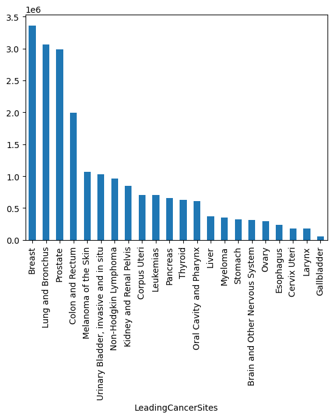

```python
df3.groupby(['LeadingCancerSites'])['Count'].sum().sort_values(ascending=False).plot.bar()
```

```python
df3.groupby(['LeadingCancerSites'])['CrudeRate'].mean().sort_values(ascending=False)
```

```
LeadingCancerSites
Prostate                                 137.207143
Breast                                    75.878571
Lung and Bronchus                         69.335714
Colon and Rectum                          45.128571
Corpus Uteri                              31.335714
Melanoma of the Skin                      24.035714
Urinary Bladder, invasive and in situ     23.207143
Non-Hodgkin Lymphoma                      21.742857
Kidney and Renal Pelvis                   19.085714
Leukemias                                 15.807143
Pancreas                                  14.785714
Thyroid                                   14.292857
Oral Cavity and Pharynx                   13.642857
Ovary                                     13.292857
Liver                                      8.300000
Cervix Uteri                               7.957143
Myeloma                                    7.842857
Stomach                                    7.407143
Brain and Other Nervous System             7.150000
Esophagus                                  5.442857
Larynx                                     3.985714
Gallbladder                                1.271429
Name: CrudeRate, dtype: float64
```

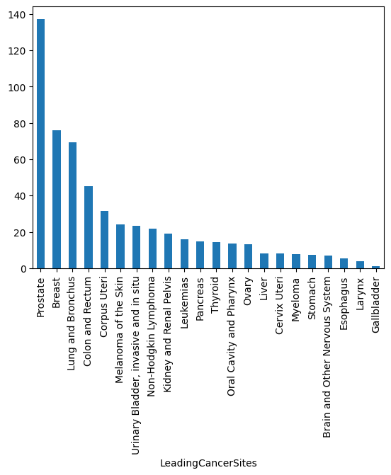

```python
df3.groupby(['LeadingCancerSites'])['CrudeRate'].mean().sort_values(ascending=False).plot.bar()
```

Secondly, I aim to examine the variations in incidence rates for various types of cancer throughout these years.

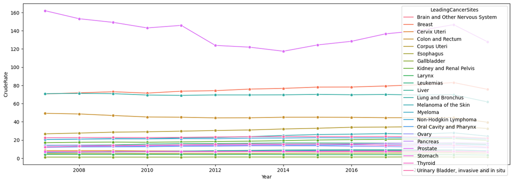

```python
import seaborn as sns

plt.figure(figsize=(18, 6))
sns.lineplot(data=df3, x='Year', y='CrudeRate', hue='LeadingCancerSites', ci=None, marker='o')
```

Prostate cancer exhibits the highest incidence rate.

As for the funding, we can also look at the change in total fundings related to cancer.

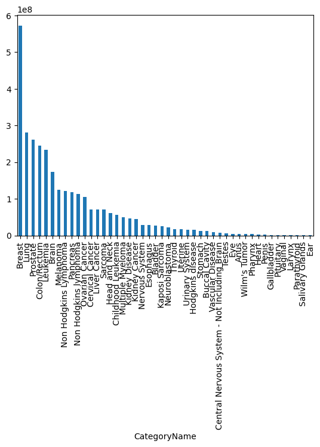

```python
funding2.groupby(['CategoryName'])['TotalFundedAmount'].mean().sort_values(ascending=False).plot.bar()
```

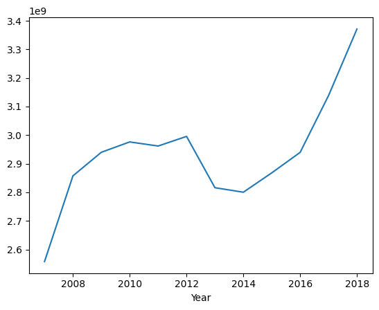

```python
funding2.groupby('Year').TotalFundedAmount.sum().plot.line()
```

After reviewing the data, it became apparent that the lower funding in 2007 is attributed to numerous missing values for that year. Consequently, I have decided to exclude the 2007 values from my analysis.

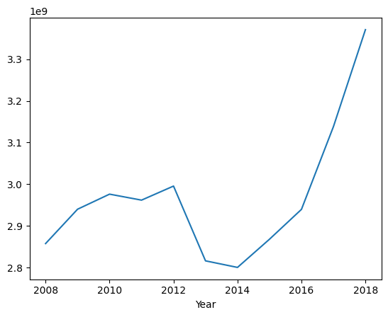

```python
funding3 =  funding2[funding2['Year'] != 2007]
funding3.groupby('Year').TotalFundedAmount.sum().plot.line()
```

Additionally, funding for cancer research is closely linked to the Gross Domestic Product (GDP). To provide a comprehensive analysis, I have included annual GDP data from 2008 to 2020, sourced from the U.S. Bureau of Economic Analysis. This inclusion allows for a better understanding of how economic fluctuations might influence cancer research funding over these years.

```python
# GDP data
gdp_data = {
    "Year": [2008, 2009, 2010, 2011, 2012, 2013, 2014, 2015, 2016, 2017, 2018, 2019, 2020],
    "GDP (in Billion USD)": [
        14712.8, 14448.9, 14992.1, 15542.6, 16197.0, 16784.9, 17527.3, 18238.3,
        18745.1, 19543.0, 20611.9, 21433.2, 21137.6
    ]
}

# Creating a DataFrame
gdp_df = pd.DataFrame(gdp_data)
```

```python
#merge cancer incidence data and cpi data
df4 = pd.merge(df3, gdp_df, on='Year')
display(df4.head())
```

|  | LeadingCancerSites | Year | CrudeRate | Count | GDP (in Billion USD) |
| --- | --- | --- | --- | --- | --- |
| 0 | Brain and Other Nervous System | 2008 | 7.2 | 21753 | 14712.8 |
| 1 | Breast | 2008 | 71.8 | 218323 | 14712.8 |
| 2 | Cervix Uteri | 2008 | 8.3 | 12756 | 14712.8 |
| 3 | Colon and Rectum | 2008 | 48.6 | 147709 | 14712.8 |
| 4 | Corpus Uteri | 2008 | 27.6 | 42626 | 14712.8 |

I am interested in how funding are allocated in different kinds of cancer. To visually emphasize the top five cancers receiving the most funding, I have employed distinct colors to highlight these categories in the chart.

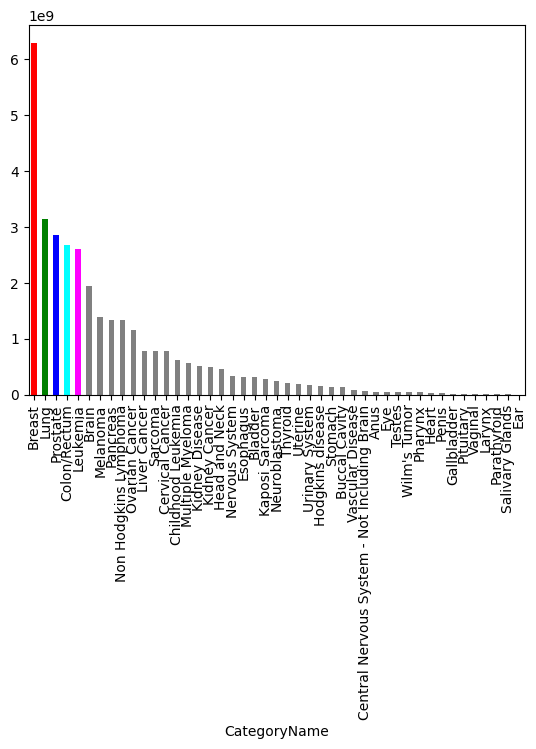

```python
grouped_data = funding3.groupby('CategoryName')['TotalFundedAmount'].sum().sort_values(ascending=False)
colors = ['red', 'green', 'blue', 'cyan', 'magenta']
rest_color = 'grey'
bar_colors = [colors[i] if i < len(colors) else rest_color for i in range(len(grouped_data))]
grouped_data.plot.bar(color=bar_colors)
plt.show()
```

Breast cancer ranks as the number one cancer in terms of receiving the highest funding, followed by lung cancer.

Next, I plan to merge the funding data with the cancer incidence data. However, before proceeding, it's important to ensure that both datasets use consistent naming conventions for a smooth merging process.

```python
unique_categories_per_year = funding3.groupby('Year')['CategoryName'].unique()
for year, categories in unique_categories_per_year.items():
    print(f"Year: {year}, Categories: {categories}")
```

```
Year: 2008, Categories: ['Anus' 'Bladder' 'Brain' 'Breast' 'Buccal Cavity'
 'Central Nervous System - Not Including Brain' 'Cervical Cancer'
 'Childhood Leukemia' 'Colon/Rectum' 'Ear' 'Esophagus' 'Eye' 'Gallbladder'
 'Head and Neck' 'Heart' 'Hodgkins disease' 'Kaposi Sarcoma'
 'Kidney Cancer' 'Kidney Disease' 'Larynx' 'Leukemia' 'Liver Cancer'
 'Lung' 'Melanoma' 'Multiple Myeloma' 'Nervous System' 'Neuroblastoma'
 'Non Hodgkins Lymphoma' 'Ovarian Cancer' 'Pancreas' 'Parathyroid' 'Penis'
 'Pharynx' 'Pituitary' 'Prostate' 'Salivary Glands' 'Sarcoma' 'Stomach'
 'Thyroid' 'Uterine' 'Vascular Disease' "Wilm's Tumor"]
Year: 2009, Categories: ['Anus' 'Bladder' 'Brain' 'Breast' 'Buccal Cavity'
 'Central Nervous System - Not Including Brain' 'Cervical Cancer'
 'Childhood Leukemia' 'Colon/Rectum' 'Esophagus' 'Eye' 'Gallbladder'
 'Head and Neck' 'Heart' 'Hodgkins disease' 'Kaposi Sarcoma'
 'Kidney Cancer' 'Kidney Disease' 'Larynx' 'Leukemia' 'Liver Cancer'
 'Lung' 'Melanoma' 'Multiple Myeloma' 'Nervous System' 'Neuroblastoma'
 'Non Hodgkins Lymphoma' 'Ovarian Cancer' 'Pancreas' 'Parathyroid' 'Penis'
 'Pharynx' 'Pituitary' 'Prostate' 'Salivary Glands' 'Sarcoma' 'Stomach'
 'Testes' 'Thyroid' 'Urinary System' 'Uterine' 'Vaginal'
 'Vascular Disease' "Wilm's Tumor"]
Year: 2010, Categories: ['Anus' 'Bladder' 'Brain' 'Breast' 'Buccal Cavity'
 'Central Nervous System - Not Including Brain' 'Cervical Cancer'
 'Childhood Leukemia' 'Colon/Rectum' 'Esophagus' 'Eye' 'Gallbladder'
 'Heart' 'Hodgkins disease' 'Kaposi Sarcoma' 'Kidney Cancer'
 'Kidney Disease' 'Larynx' 'Leukemia' 'Liver Cancer' 'Lung' 'Melanoma'
 'Multiple Myeloma' 'Nervous System' 'Neuroblastoma'
 'Non Hodgkins Lymphoma' 'Ovarian Cancer' 'Pancreas' 'Parathyroid' 'Penis'
 'Pharynx' 'Pituitary' 'Prostate' 'Salivary Glands' 'Sarcoma' 'Stomach'
 'Testes' 'Thyroid' 'Urinary System' 'Uterine' 'Vaginal'
 'Vascular Disease' "Wilm's Tumor"]
Year: 2011, Categories: ['Anus' 'Bladder' 'Brain' 'Breast' 'Buccal Cavity'
 'Central Nervous System - Not Including Brain' 'Cervical Cancer'
 'Childhood Leukemia' 'Colon/Rectum' 'Esophagus' 'Eye' 'Gallbladder'
 'Heart' 'Hodgkins disease' 'Kaposi Sarcoma' 'Kidney Cancer'
 'Kidney Disease' 'Larynx' 'Leukemia' 'Liver Cancer' 'Lung' 'Melanoma'
 'Multiple Myeloma' 'Nervous System' 'Neuroblastoma'
 'Non Hodgkins Lymphoma' 'Ovarian Cancer' 'Pancreas' 'Parathyroid' 'Penis'
 'Pharynx' 'Pituitary' 'Prostate' 'Salivary Glands' 'Sarcoma' 'Stomach'
 'Testes' 'Thyroid' 'Urinary System' 'Uterine' 'Vaginal'
 'Vascular Disease' "Wilm's Tumor"]
Year: 2012, Categories: ['Anus' 'Bladder' 'Brain' 'Breast' 'Buccal Cavity'
```

[output cut: 54 more lines]

```
 'Lung' 'Melanoma' 'Multiple Myeloma' 'Nervous System' 'Neuroblastoma'
 'Non Hodgkins Lymphoma' 'Ovarian Cancer' 'Pancreas' 'Parathyroid' 'Penis'
 'Pharynx' 'Pituitary' 'Prostate' 'Salivary Glands' 'Sarcoma' 'Stomach'
 'Testes' 'Thyroid' 'Urinary System' 'Uterine' 'Vaginal'
 'Vascular Disease' "Wilm's Tumor"]
Year: 2018, Categories: ['Anus' 'Bladder' 'Brain' 'Breast' 'Buccal Cavity'
 'Central Nervous System - Not Including Brain' 'Cervical Cancer'
 'Childhood Leukemia' 'Colon/Rectum' 'Esophagus' 'Eye' 'Gallbladder'
 'Head and Neck' 'Heart' 'Hodgkins disease' 'Kaposi Sarcoma'
 'Kidney Cancer' 'Kidney Disease' 'Larynx' 'Leukemia' 'Liver Cancer'
 'Lung' 'Melanoma' 'Multiple Myeloma' 'Nervous System' 'Neuroblastoma'
 'Non Hodgkins Lymphoma' 'Ovarian Cancer' 'Pancreas' 'Parathyroid' 'Penis'
 'Pharynx' 'Pituitary' 'Prostate' 'Salivary Glands' 'Sarcoma' 'Stomach'
 'Testes' 'Thyroid' 'Urinary System' 'Uterine' 'Vaginal'
 'Vascular Disease' "Wilm's Tumor"]
```

```python
df4['LeadingCancerSites'].unique()
```

```
array(['Brain and Other Nervous System', 'Breast', 'Cervix Uteri',
       'Colon and Rectum', 'Corpus Uteri', 'Esophagus', 'Gallbladder',
       'Kidney and Renal Pelvis', 'Larynx', 'Leukemias', 'Liver',
       'Lung and Bronchus', 'Melanoma of the Skin', 'Myeloma',
       'Non-Hodgkin Lymphoma', 'Oral Cavity and Pharynx', 'Ovary',
       'Pancreas', 'Prostate', 'Stomach', 'Thyroid',
       'Urinary Bladder, invasive and in situ'], dtype=object)
```

The incidence data contains fewer categories compared to the funding data. To address this, I will create new categories based on the types present in the incidence data.

```python
#suming brain and Central Nervous System to Brain and Other Nervous System
funding4 = funding3.copy()
funding4['CategoryName'] = funding4['CategoryName'].replace(['Brain', 'Central Nervous System - Not Including Brain'], 'Brain and Other Nervous System')
#chaning name for Cervical Cancer
funding4['CategoryName'] = funding4['CategoryName'].replace('Cervical Cancer', 'Cervix Uteri')
#chaning name for Colon/Rectum
funding4['CategoryName'] = funding4['CategoryName'].replace('Colon/Rectum', 'Colon and Rectum')
#suming  'Kidney Cancer' and 'Kidney Disease' to Kidney and Renal Pelvis
funding4['CategoryName'] = funding4['CategoryName'].replace([ 'Kidney Cancer', 'Kidney Disease'], 'Kidney and Renal Pelvis')
#suming  'Leukemia' and 'Childhood Leukemia' to Leukemias
funding4['CategoryName'] = funding4['CategoryName'].replace([ 'Kidney Cancer', 'Kidney Disease'], 'Leukemias')
#chaning name for Liver Cancer
funding4['CategoryName'] = funding4['CategoryName'].replace('Liver Cancer', 'Liver')
#chaning name for Lung and Bronchus
funding4['CategoryName'] = funding4['CategoryName'].replace('Lung', 'Lung and Bronchus')
#chaning name for Melanoma of the Skin
funding4['CategoryName'] = funding4['CategoryName'].replace('Melanoma', 'Melanoma of the Skin')
#chaning name for Myeloma
funding4['CategoryName'] = funding4['CategoryName'].replace('Multiple Myeloma', 'Myeloma')
#chaning name for Non-Hodgkin Lymphoma
funding4['CategoryName'] = funding4['CategoryName'].replace('Non Hodgkin Lymphoma', 'Non-Hodgkin Lymphoma')
#chaning name for Oral Cavity and Pharynx
funding4['CategoryName'] = funding4['CategoryName'].replace('Pharynx', 'Oral Cavity and Pharynx')
#chaning name for Ovarian Cancer
funding4['CategoryName'] = funding4['CategoryName'].replace('Ovarian Cancer', 'Ovarian')
#suming  'Bladder', 'Urinary System' to Urinary Bladder
funding4['CategoryName'] = funding4['CategoryName'].replace([ 'Bladder', 'Urinary System'], 'Urinary Bladder')



funding5 = funding4.groupby(['Year', 'CategoryName'])['TotalFundedAmount'].sum().reset_index()
display(funding5.head(10))
```

|  | Year | CategoryName | TotalFundedAmount |
| --- | --- | --- | --- |
| 0 | 2008 | Anus | 3120001 |
| 1 | 2008 | Brain and Other Nervous System | 153731417 |
| 2 | 2008 | Breast | 572597443 |
| 3 | 2008 | Buccal Cavity | 7357884 |
| 4 | 2008 | Cervix Uteri | 76788322 |
| 5 | 2008 | Childhood Leukemia | 48267255 |
| 6 | 2008 | Colon and Rectum | 273721430 |
| 7 | 2008 | Ear | 165314 |
| 8 | 2008 | Esophagus | 22441827 |
| 9 | 2008 | Eye | 3083451 |

```python
#merge cancer incidence data and funding data
funding5 = funding5.rename(columns={'CategoryName':'LeadingCancerSites'})
df5 = pd.merge(funding5, df4, on=['LeadingCancerSites','Year'])
display(df5.head(10))
```

|  | Year | LeadingCancerSites | TotalFundedAmount | CrudeRate | Count | GDP (in Billion USD) |
| --- | --- | --- | --- | --- | --- | --- |
| 0 | 2008 | Brain and Other Nervous System | 153731417 | 7.2 | 21753 | 14712.8 |
| 1 | 2008 | Breast | 572597443 | 71.8 | 218323 | 14712.8 |
| 2 | 2008 | Cervix Uteri | 76788322 | 8.3 | 12756 | 14712.8 |
| 3 | 2008 | Colon and Rectum | 273721430 | 48.6 | 147709 | 14712.8 |
| 4 | 2008 | Esophagus | 22441827 | 5.4 | 16373 | 14712.8 |
| 5 | 2008 | Gallbladder | 975977 | 1.2 | 3567 | 14712.8 |
| 6 | 2008 | Kidney and Renal Pelvis | 86863366 | 17.5 | 53103 | 14712.8 |
| 7 | 2008 | Larynx | 244021 | 4.2 | 12652 | 14712.8 |
| 8 | 2008 | Liver | 74234589 | 6.8 | 20822 | 14712.8 |
| 9 | 2008 | Lung and Bronchus | 247569163 | 71.2 | 216423 | 14712.8 |